# Reproducible Research - Course Project 1

Junaid Ishaq

1/24/2020

## Main Tasks

1. Loading and preprocessing the data
   - Load the data
   - Process/transform the data (if necessary)
2. Calculating mean total number of steps taken per day
   - Total number of steps taken per day
   - Make a histogram of the total number of steps taken each day
   - Report the mean and median of the total number of steps taken per day
3. Average daily activity pattern
   - Make a time series plot of the 5-minute interval and the average number of steps taken, averaged across all days
   - Determine 5-minutes interval containing the maximum number of steps
4. Imputing missing values
   - Report the total number of missing values in the dataset
   - Fill in all of the missing values
   - Create a new dataset that is equal to the original dataset but with the missing data filled in
   - Make a histogram of the total number of steps taken each day
   - Report the mean and median of the total number of steps taken per day
   - Report the difference in mean, median and total number of steps in new and old datasets
5. Differences in activity patterns between weekdays and weekends
   - Create a new factor variable in the dataset with two levels – “weekday” and “weekend”
   - Make a panel plot containing a time series plot of the 5-minute interval and the average number of steps taken, averaged across all weekday days or weekend days

## 1. Loading and preprocessing the data

### 1.1 Data loading

```r
library(knitr, warn.conflicts = FALSE)
library(dplyr, warn.conflicts = FALSE)
library(ggplot2, warn.conflicts = FALSE)
library(kableExtra, warn.conflicts = FALSE)

setwd("C:/Users/junai/Desktop")
activity <- read.csv("activity.csv")
```

### 1.2 Data preprocessing/transforming

Not required!

## 2. Calculating mean total number of steps taken per day

### 2.1 Total number of steps

```r
total_steps <- sum(activity$steps, na.rm = TRUE)
cat("Total number of steps: ", total_steps)
```

```
## Total number of steps:  570608
```

### Reporting the total, mean and median for steps taken per day

```r
# calculate steps total, mean, median and number of NAs for each day
date_stats <- activity %>%
              group_by(date) %>%
              summarise(Total = sum(steps, na.rm=TRUE),
                        Mean = mean(steps, na.rm=TRUE),
                        Median = median(steps, na.rm=TRUE),
                        NAs = sum(is.na(steps)))

date_stats %>%
  knitr::kable(format="html", digits=0) %>%
  kable_styling(bootstrap_options = "striped",
              full_width = F,
              position = "center")
```

| date | Total | Mean | Median | NAs |
| --- | --- | --- | --- | --- |
| 2012-10-01 | 0 | NaN | NA | 288 |
| 2012-10-02 | 126 | 0 | 0 | 0 |
| 2012-10-03 | 11352 | 39 | 0 | 0 |
| 2012-10-04 | 12116 | 42 | 0 | 0 |
| 2012-10-05 | 13294 | 46 | 0 | 0 |
| 2012-10-06 | 15420 | 54 | 0 | 0 |
| 2012-10-07 | 11015 | 38 | 0 | 0 |
| 2012-10-08 | 0 | NaN | NA | 288 |
| 2012-10-09 | 12811 | 44 | 0 | 0 |
| 2012-10-10 | 9900 | 34 | 0 | 0 |
| 2012-10-11 | 10304 | 36 | 0 | 0 |
| 2012-10-12 | 17382 | 60 | 0 | 0 |
| 2012-10-13 | 12426 | 43 | 0 | 0 |
| 2012-10-14 | 15098 | 52 | 0 | 0 |
| 2012-10-15 | 10139 | 35 | 0 | 0 |
| 2012-10-16 | 15084 | 52 | 0 | 0 |
| 2012-10-17 | 13452 | 47 | 0 | 0 |
| 2012-10-18 | 10056 | 35 | 0 | 0 |
| 2012-10-19 | 11829 | 41 | 0 | 0 |
| 2012-10-20 | 10395 | 36 | 0 | 0 |
| 2012-10-21 | 8821 | 31 | 0 | 0 |
| 2012-10-22 | 13460 | 47 | 0 | 0 |
| 2012-10-23 | 8918 | 31 | 0 | 0 |
| 2012-10-24 | 8355 | 29 | 0 | 0 |
| 2012-10-25 | 2492 | 9 | 0 | 0 |
| 2012-10-26 | 6778 | 24 | 0 | 0 |
| 2012-10-27 | 10119 | 35 | 0 | 0 |
| 2012-10-28 | 11458 | 40 | 0 | 0 |
| 2012-10-29 | 5018 | 17 | 0 | 0 |
| 2012-10-30 | 9819 | 34 | 0 | 0 |
| 2012-10-31 | 15414 | 54 | 0 | 0 |
| 2012-11-01 | 0 | NaN | NA | 288 |
| 2012-11-02 | 10600 | 37 | 0 | 0 |
| 2012-11-03 | 10571 | 37 | 0 | 0 |
| 2012-11-04 | 0 | NaN | NA | 288 |
| 2012-11-05 | 10439 | 36 | 0 | 0 |
| 2012-11-06 | 8334 | 29 | 0 | 0 |
| 2012-11-07 | 12883 | 45 | 0 | 0 |
| 2012-11-08 | 3219 | 11 | 0 | 0 |
| 2012-11-09 | 0 | NaN | NA | 288 |
| 2012-11-10 | 0 | NaN | NA | 288 |
| 2012-11-11 | 12608 | 44 | 0 | 0 |
| 2012-11-12 | 10765 | 37 | 0 | 0 |
| 2012-11-13 | 7336 | 25 | 0 | 0 |
| 2012-11-14 | 0 | NaN | NA | 288 |
| 2012-11-15 | 41 | 0 | 0 | 0 |
| 2012-11-16 | 5441 | 19 | 0 | 0 |
| 2012-11-17 | 14339 | 50 | 0 | 0 |
| 2012-11-18 | 15110 | 52 | 0 | 0 |
| 2012-11-19 | 8841 | 31 | 0 | 0 |
| 2012-11-20 | 4472 | 16 | 0 | 0 |
| 2012-11-21 | 12787 | 44 | 0 | 0 |
| 2012-11-22 | 20427 | 71 | 0 | 0 |
| 2012-11-23 | 21194 | 74 | 0 | 0 |
| 2012-11-24 | 14478 | 50 | 0 | 0 |
| 2012-11-25 | 11834 | 41 | 0 | 0 |
| 2012-11-26 | 11162 | 39 | 0 | 0 |
| 2012-11-27 | 13646 | 47 | 0 | 0 |
| 2012-11-28 | 10183 | 35 | 0 | 0 |
| 2012-11-29 | 7047 | 24 | 0 | 0 |
| 2012-11-30 | 0 | NaN | NA | 288 |

### 2.2 Histogram of total number of steps

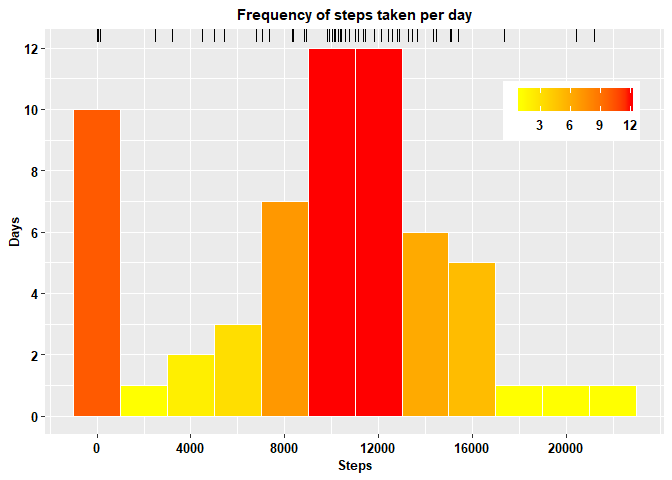

```r
g <-ggplot(date_stats, aes(x = Total))
g + geom_histogram(binwidth=2000, color="white", aes(fill=..count..)) +
    geom_rug(sides="t") +
    labs(title="Frequency of steps taken per day", x = "Steps", y = "Days") +
    scale_fill_gradient("Count", low="yellow", high="red") +
    scale_y_continuous(breaks = seq(0,12,2)) +
    scale_x_continuous(breaks = seq(0, 23000, 4000)) +
    theme(plot.title = element_text(face = "bold", color = "black", size = 11, hjust=0.5),
          axis.title = element_text(face = "bold", color = "black", size = 10),
          axis.text.x = element_text(face = "bold", color = "black", size = 10),
          axis.text.y = element_text(face = "bold", color = "black", size = 10),
          legend.title = element_blank(),
          legend.text = element_text(face = "bold", color = "black", size = 10),
          legend.position = c(0.85,0.8),
          legend.direction = "horizontal")
```

### 2.3 Mean and median for total number of steps taken per day

```r
cat("Mean for total number of steps:   ", round(mean(date_stats$Total),0))
```

```
## Mean for total number of steps:    9354
```

```r
cat("Median for total number of steps: ", median(date_stats$Total))
```

```
## Median for total number of steps:  10395
```

## 3. Average daily activity pattern

### 3.1 Time series plot of the 5-minute interval

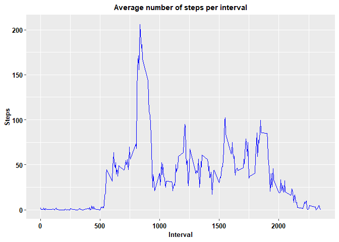

```r
interval_stats <- activity %>%
                  group_by(interval) %>%
                  summarise(Total = sum(steps, na.rm=TRUE),
                            Mean = mean(steps, na.rm=TRUE),
                            Median = median(steps, na.rm=TRUE))

# Line plot
g <-ggplot(interval_stats, aes(x = interval, y = Mean))
g + geom_line(color = "blue") +
    labs(title="Average number of steps per interval", x = "Interval", y = "Steps") +
    theme(plot.title = element_text(face = "bold", color = "black", size = 11, hjust=0.5),
          axis.title = element_text(face = "bold", color = "black", size = 10),
          axis.text.x = element_text(face = "bold", color = "black", size = 10),
          axis.text.y = element_text(face = "bold", color = "black", size = 10))
```

### 3.2 Determining the interval with maximum number of steps

```r
max <- which.max(interval_stats$Mean)
cat("Interval with maximum number of steps: ", interval_stats$interval[max])
```

```
## Interval with maximum number of steps:  835
```

## 4. Imputing missing values

### 4.1 Determining and reporting total number of missing values in the dataset

```r
cat("Total number of missing values = ", sum(is.na(activity$steps)))
```

```
## Total number of missing values =  2304
```

### 4.2 Create a new dataset

```r
activity_noNAs <- activity
```

### 4.3 Replacing missing values in the new dataset with the average value for each interval

```r
ind <- which(is.na(activity$steps)) # indices for NAs
activity_noNAs$steps[ind] <- interval_stats$Mean # replace NAs in the new dataset
```

### 4.4 Histogram of total number of steps for the new dataset

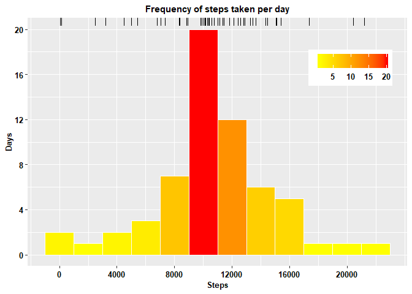

```r
date_stats_noNAs <- activity_noNAs %>%
                    group_by(date) %>%
                    summarise(Total = sum(steps, na.rm=TRUE),
                              Mean = mean(steps, na.rm=TRUE),
                              Median = median(steps, na.rm=TRUE))

g <-ggplot(date_stats_noNAs, aes(x = Total))
g + geom_histogram(binwidth=2000, color="white", aes(fill=..count..)) +
    geom_rug(sides="t") +
    labs(title="Frequency of steps taken per day", x = "Steps", y = "Days") +
    scale_fill_gradient("Count", low="yellow", high="red") +
    scale_y_continuous(breaks = seq(0,24,4)) +
    scale_x_continuous(breaks = seq(0, 23000, 4000)) +
    theme(plot.title = element_text(face = "bold", color = "black", size = 11, hjust=0.5),
          axis.title = element_text(face = "bold", color = "black", size = 10),
          axis.text.x = element_text(face = "bold", color = "black", size = 10),
          axis.text.y = element_text(face = "bold", color = "black", size = 10),
          legend.title = element_blank(),
          legend.text = element_text(face = "bold", color = "black", size = 10),
          legend.position = c(0.85,0.8),
          legend.direction = "horizontal")
```

### 4.5 Mean and median for total number of steps in the new dataset

```r
cat("New mean for total number of steps:   ", round(mean(date_stats_noNAs$Total),0))
```

```
## New mean for total number of steps:    10766
```

```r
cat("New median for total number of steps: ", round(median(date_stats_noNAs$Total),0))
```

```
## New median for total number of steps:  10766
```

```r
total_steps_new <- round(sum(activity_noNAs$steps),0)
cat("Total number of steps in new dataset:  ", total_steps_new)
```

```
## Total number of steps in new dataset:   656738
```

### 4.6 Differences in mean, median and total number of steps between the new and old datasets

```r
mean_diff <- mean(date_stats_noNAs$Total) - mean(date_stats$Total)
median_diff <- median(date_stats_noNAs$Total) - median(date_stats$Total)
total_diff <- total_steps_new - total_steps
```

```r
cat("Difference in mean:   ", round(mean_diff,0))
```

```
## Difference in mean:    1412
```

```r
cat("Difference in median: ", round(median_diff,0))
```

```
## Difference in median:  371
```

```r
cat("Difference in total number of steps:   ", total_diff)
```

```
## Difference in total number of steps:    86130
```

## 5. Activity patterns for weekdays and weekends

### 5.1 Creating a new factor variable for weekdays and weekends

```r
dates <- as.Date(activity$date)
Day <- weekdays(dates)

activity_noNAs <- cbind(activity_noNAs, Day, Day_type = Day)

wd <- c("Monday", "Tuesday", "Wednesday", "Thursday", "Friday")
we <- c("Saturday", "Sunday")

activity_noNAs$Day_type <- as.character(activity_noNAs$Day_type)
activity_noNAs$Day_type[which(Day %in% wd)] <- "Weekday"
activity_noNAs$Day_type[which(Day %in% we)] <- "Weekend"
activity_noNAs$Day_type <- as.factor(activity_noNAs$Day_type)
```

### 5.2 Plotting the average of each interval for weekdays and weekends

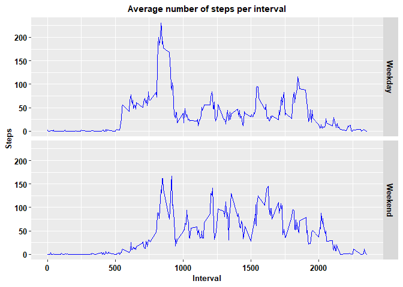

```r
wday_avg <- activity_noNAs %>%
            filter(Day_type=="Weekday") %>%
            group_by(interval) %>%
            summarise(Average = mean(steps))
wday_avg$Day <- as.factor("Weekday")

wend_avg <- activity_noNAs %>%
            filter(Day_type=="Weekend") %>%
            group_by(interval) %>%
            summarise(Average = mean(steps))
wend_avg$Day <- as.factor("Weekend")

wday_wend <- rbind(wday_avg, wend_avg)

# Line plot for weekdays and weekends
g <-ggplot(data = wday_wend, aes(x = interval, y = Average))
g + geom_line(color = "blue") +
    facet_grid(Day ~ ., scales = "fixed") +
    labs(title = "Average number of steps per interval", x = "Interval", y = "Steps") +
    theme(plot.title = element_text(face = "bold", color = "black", size = 11, hjust=0.5),
          axis.title = element_text(face = "bold", color = "black", size = 10),
          axis.text.x = element_text(face = "bold", color = "black", size = 10),
          axis.text.y = element_text(face = "bold", color = "black", size = 10),
          strip.text = element_text(face = "bold", color = "black", size = 10))
```